# Basic Data Visualization in R

[Example]

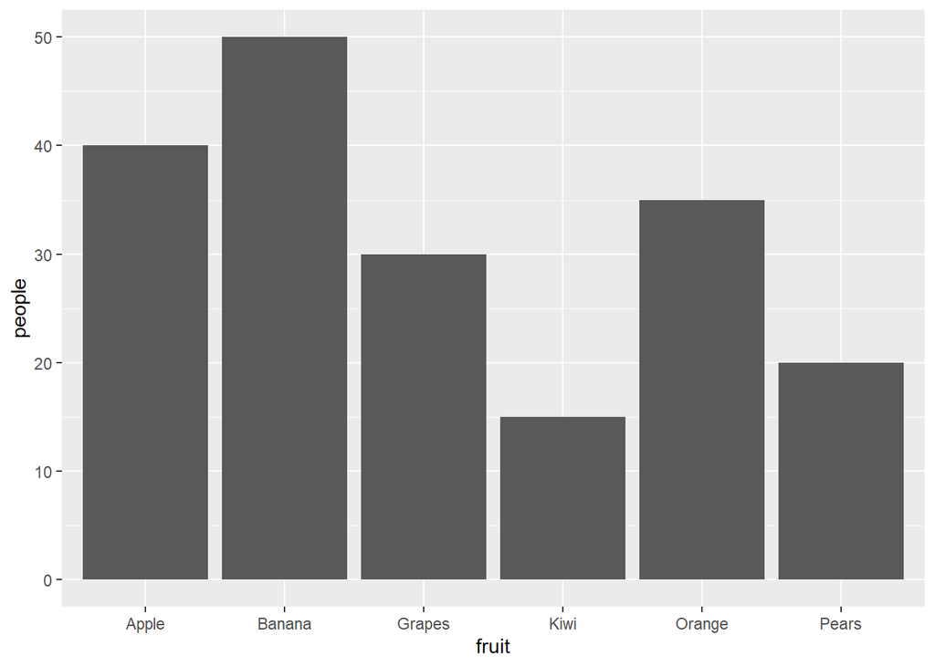

```r
ggplot(data = survey, aes(x=fruit, y=people)) +
  geom_bar(stat = "identity")
```

```r
#The argument "stat = identity" is telling it not to transform the data.
```

Additional Arguments

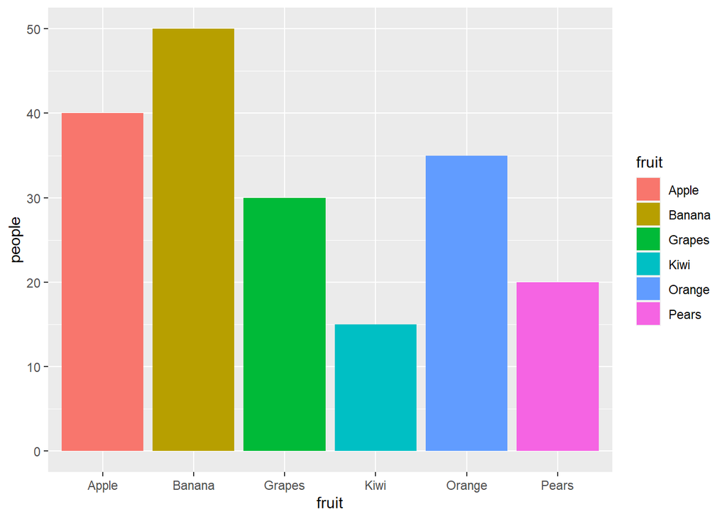

```r
#Make bars with color
ggplot(survey, aes(x=fruit, y=people, fill=fruit)) +
  geom_bar(stat="identity")
```

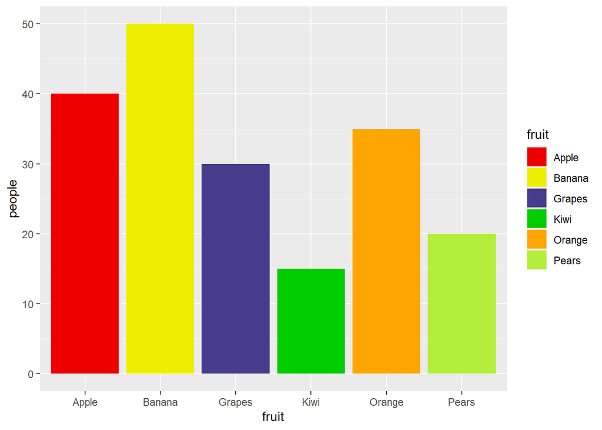

```r
#Make bars with specific color
ggplot(survey, aes(x=fruit, y=people, fill=fruit)) +
  geom_bar(stat="identity") +
  scale_fill_manual(values=c("red2", "yellow2", "slateblue4", "green3", "orange", "olivedrab2"))
```

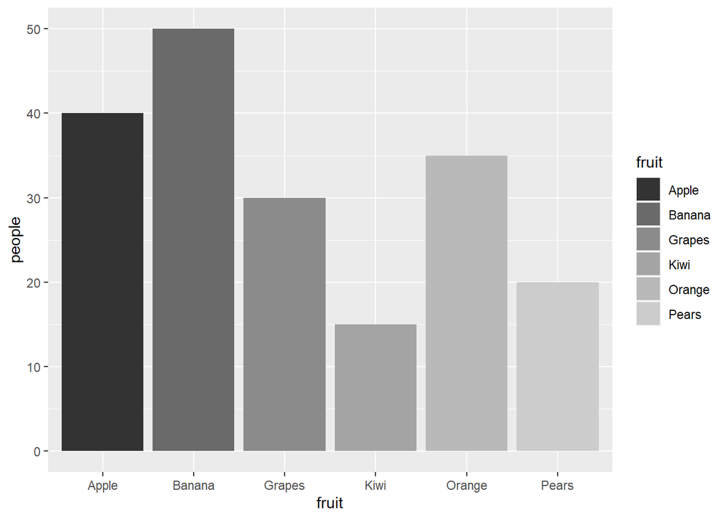

```r
#Make bars with grey scale
ggplot(survey, aes(x=fruit, y=people, fill=fruit)) +
  geom_bar(stat="identity") +
  scale_fill_grey()
```

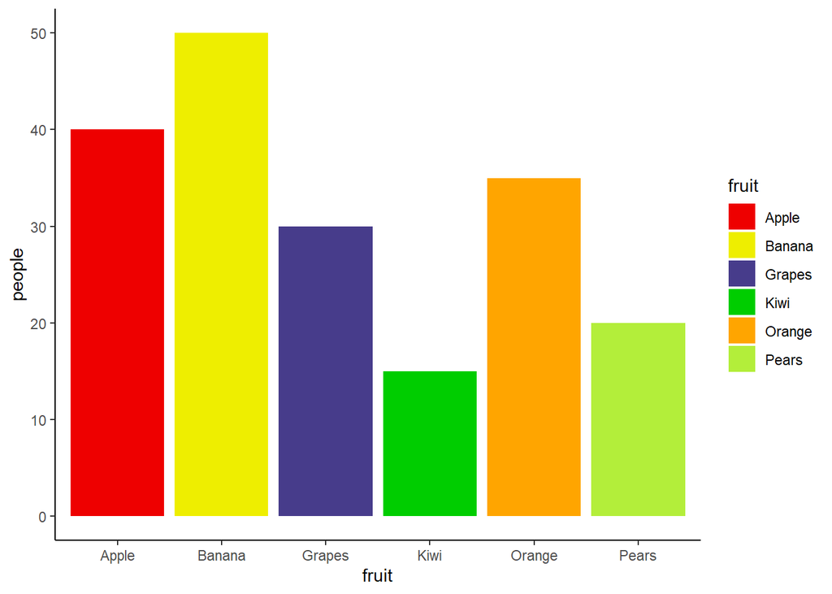

```r
#Make it in different theme
ggplot(survey, aes(x=fruit, y=people, fill=fruit)) +
  scale_fill_manual(values=c("red2", "yellow2", "slateblue4", "green3", "orange", "olivedrab2")) +
  geom_bar(stat="identity") +
  theme_classic()
```

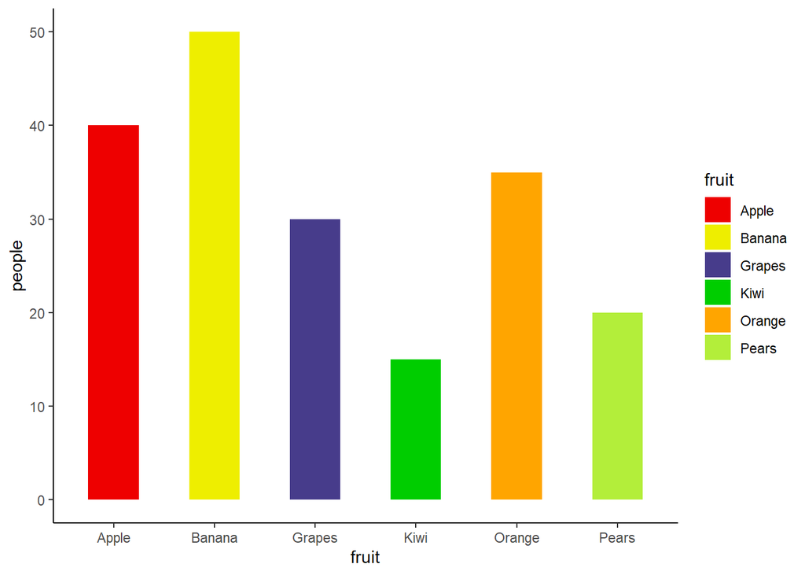

```r
#Modify bar width
ggplot(survey, aes(x=fruit, y=people, fill=fruit)) +
  scale_fill_manual(values=c("red2", "yellow2", "slateblue4", "green3", "orange", "olivedrab2")) +
  geom_bar(stat="identity", width = 0.5) +
  theme_classic()
```

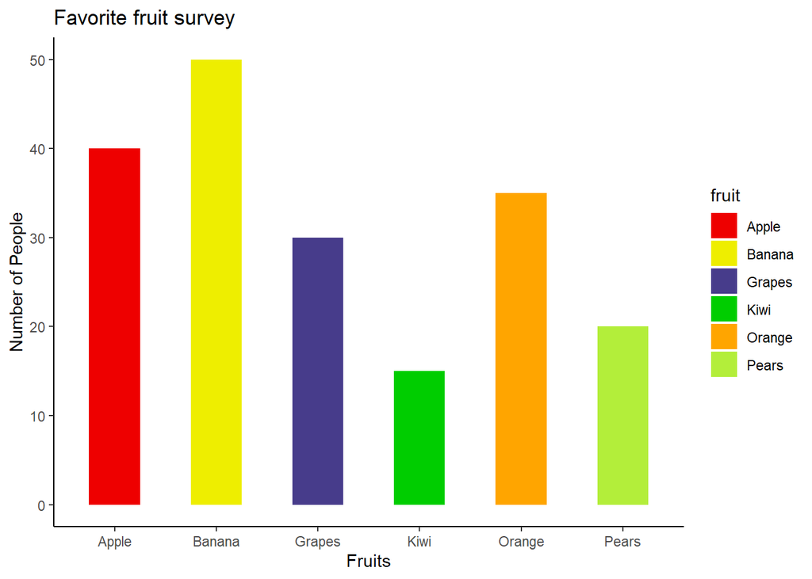

```r
#Add titiles and label axes
ggplot(survey, aes(x=fruit, y=people, fill=fruit)) +
  scale_fill_manual(values=c("red2", "yellow2", "slateblue4", "green3", "orange", "olivedrab2")) +
  geom_bar(stat="identity", width = 0.5) +
  theme_classic() +
  ggtitle("Favorite fruit survey") +
  xlab("Fruits") +
  ylab("Number of People")
```

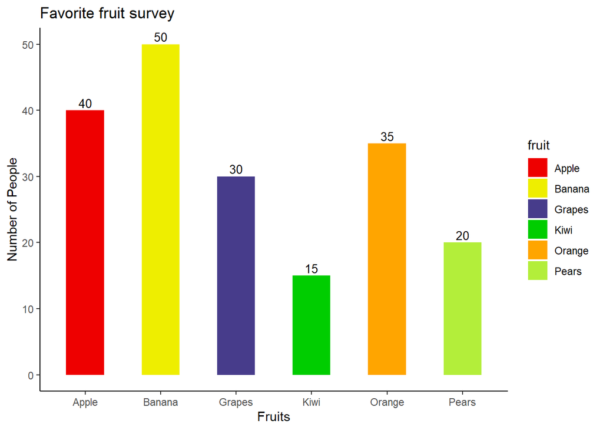

```r
#add labels

ggplot(survey, aes(x=fruit, y=people, fill=fruit)) +
  scale_fill_manual(values=c("red2", "yellow2", "slateblue4", "green3", "orange", "olivedrab2")) +
  geom_bar(stat="identity", width = 0.5) +
  geom_text(aes(label=people), vjust=-0.3, size=3.5) +
  theme_classic() +
  ggtitle("Favorite fruit survey") +
  xlab("Fruits") +
  ylab("Number of People")
```

**Line Graph**

Here, we will use a different data set called “Orange”.

[Code] ggplot(data = ) + geom_line(mapping = aes())

[Example]

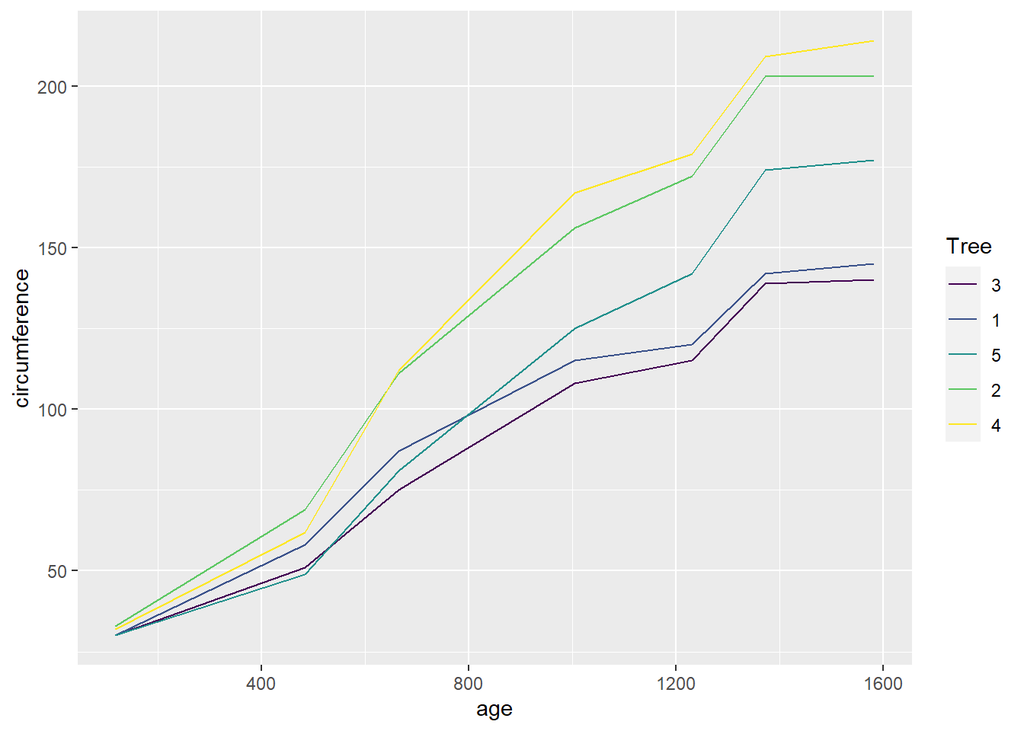

```r
#Circumference vs. Age
ggplot(data = Orange) +
  geom_line(mapping = aes(x = age, y = circumference, color = Tree))
```

Now, we will create a line graph for tree 1 only.

```r
head(Orange)
```

```
##   Tree  age circumference
## 1    1  118            30
## 2    1  484            58
## 3    1  664            87
## 4    1 1004           115
## 5    1 1231           120
## 6    1 1372           142
```

```r
#Select the data for tree 1 and create a new data frame with it
tree_1 <- Orange[which(Orange$Tree==1),]
tree_1
```

```
##   Tree  age circumference
## 1    1  118            30
## 2    1  484            58
## 3    1  664            87
## 4    1 1004           115
## 5    1 1231           120
## 6    1 1372           142
## 7    1 1582           145
```

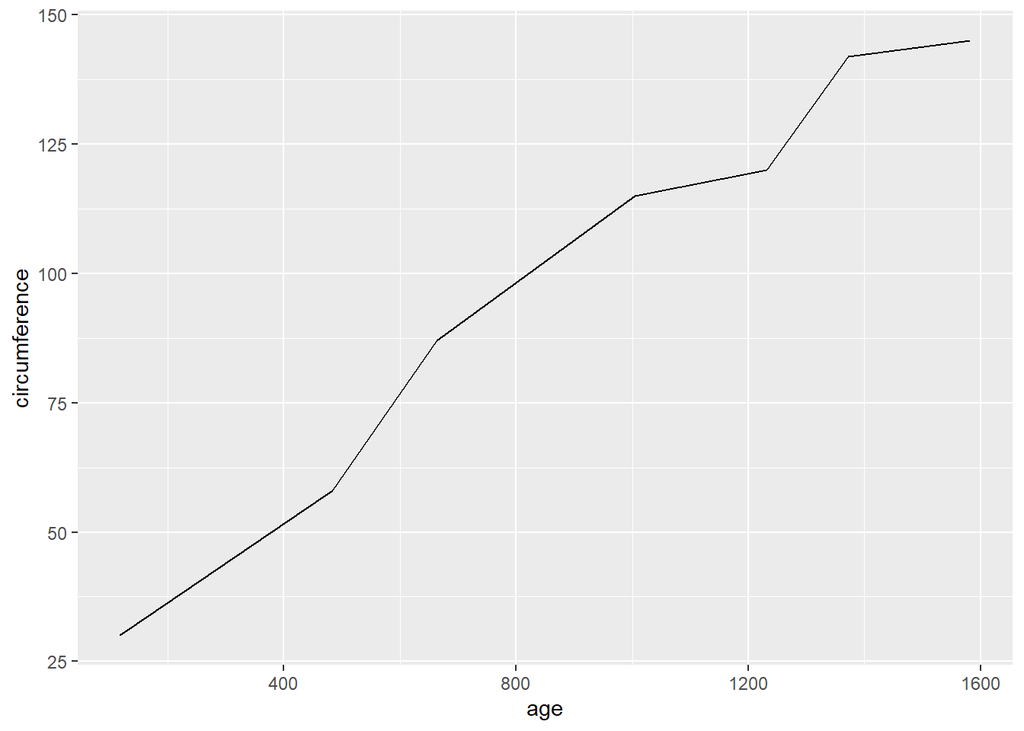

```r
ggplot(data = tree_1) +
  geom_line(mapping = aes(x = age, y = circumference))
```

Additional Arguments

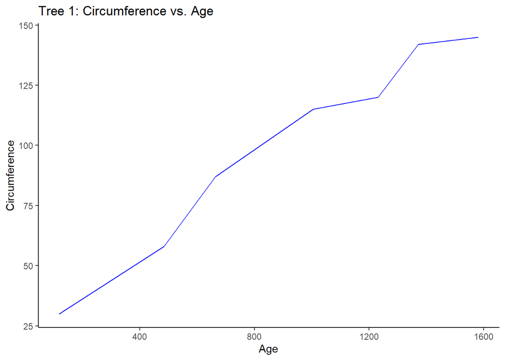

```r
#Give color to the line
ggplot(data = tree_1) +
  geom_line(mapping = aes(x = age, y = circumference), color = "blue") +
  theme_classic() +
  ggtitle("Tree 1: Circumference vs. Age") +
  xlab("Age") +
  ylab("Circumference")
```

**Scatter Plot with Line Added**

In the section, we will use “swiss” data set and learn how to add a line to a scatter plot.

This data set shows the standardized fertility measure and socio-economic indicators for each of 47 French-speaking provinces of Switzerland at about 1888.

```r
swiss
```

[output not shown]

[output cut: 41 more lines]

[output not shown]

```r
head(swiss)
```

```
##              Fertility Agriculture Examination Education Catholic
## Courtelary        80.2        17.0          15        12     9.96
## Delemont          83.1        45.1           6         9    84.84
## Franches-Mnt      92.5        39.7           5         5    93.40
## Moutier           85.8        36.5          12         7    33.77
## Neuveville        76.9        43.5          17        15     5.16
## Porrentruy        76.1        35.3           9         7    90.57
##              Infant.Mortality
## Courtelary               22.2
## Delemont                 22.2
## Franches-Mnt             20.2
## Moutier                  20.3
## Neuveville               20.6
## Porrentruy               26.6
```

```r
summary(swiss)
```

```
##    Fertility      Agriculture     Examination      Education
##  Min.   :35.00   Min.   : 1.20   Min.   : 3.00   Min.   : 1.00
##  1st Qu.:64.70   1st Qu.:35.90   1st Qu.:12.00   1st Qu.: 6.00
##  Median :70.40   Median :54.10   Median :16.00   Median : 8.00
##  Mean   :70.14   Mean   :50.66   Mean   :16.49   Mean   :10.98
##  3rd Qu.:78.45   3rd Qu.:67.65   3rd Qu.:22.00   3rd Qu.:12.00
##  Max.   :92.50   Max.   :89.70   Max.   :37.00   Max.   :53.00
##     Catholic       Infant.Mortality
##  Min.   :  2.150   Min.   :10.80
##  1st Qu.:  5.195   1st Qu.:18.15
##  Median : 15.140   Median :20.00
##  Mean   : 41.144   Mean   :19.94
##  3rd Qu.: 93.125   3rd Qu.:21.70
##  Max.   :100.000   Max.   :26.60
```

```r
str(swiss)
```

```
## 'data.frame':    47 obs. of  6 variables:
##  $ Fertility       : num  80.2 83.1 92.5 85.8 76.9 76.1 83.8 92.4 82.4 82.9 ...
##  $ Agriculture     : num  17 45.1 39.7 36.5 43.5 35.3 70.2 67.8 53.3 45.2 ...
##  $ Examination     : int  15 6 5 12 17 9 16 14 12 16 ...
##  $ Education       : int  12 9 5 7 15 7 7 8 7 13 ...
##  $ Catholic        : num  9.96 84.84 93.4 33.77 5.16 ...
##  $ Infant.Mortality: num  22.2 22.2 20.2 20.3 20.6 26.6 23.6 24.9 21 24.4 ...
```

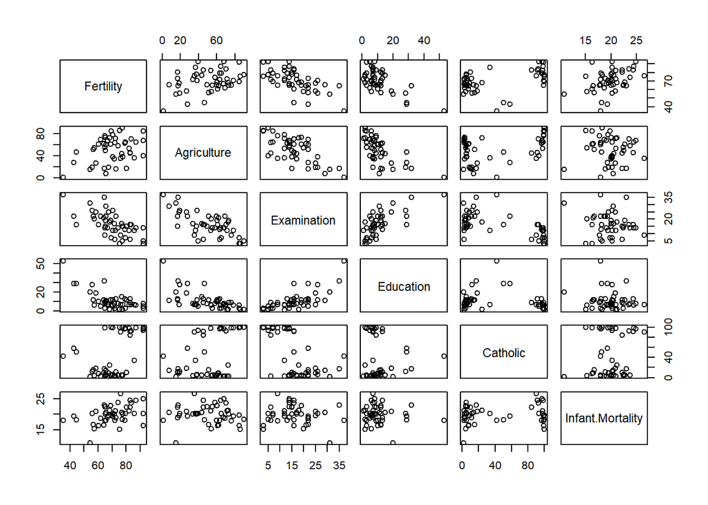

```r
plot(swiss)
```

First, we will use basic function called “plot()” to graph.

[Code] plot() abline(lm(MAPPINGS)) - For the mapping of plot() function, x variable comes first followed by y variable. - For the mapping of abline() function, y variable comes first followed by x variable.

[Example]

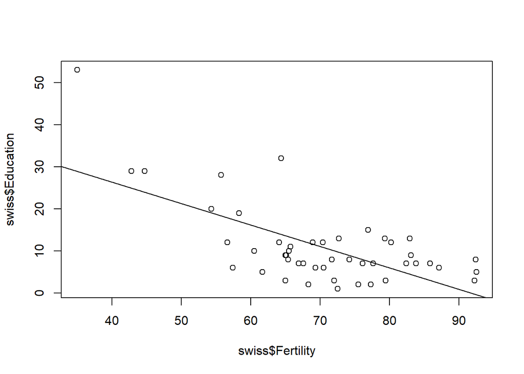

```r
#1) Education vs. Fertility
plot(swiss$Fertility, swiss$Education)
#Add line
abline(lm(swiss$Education ~ swiss$Fertility))
```

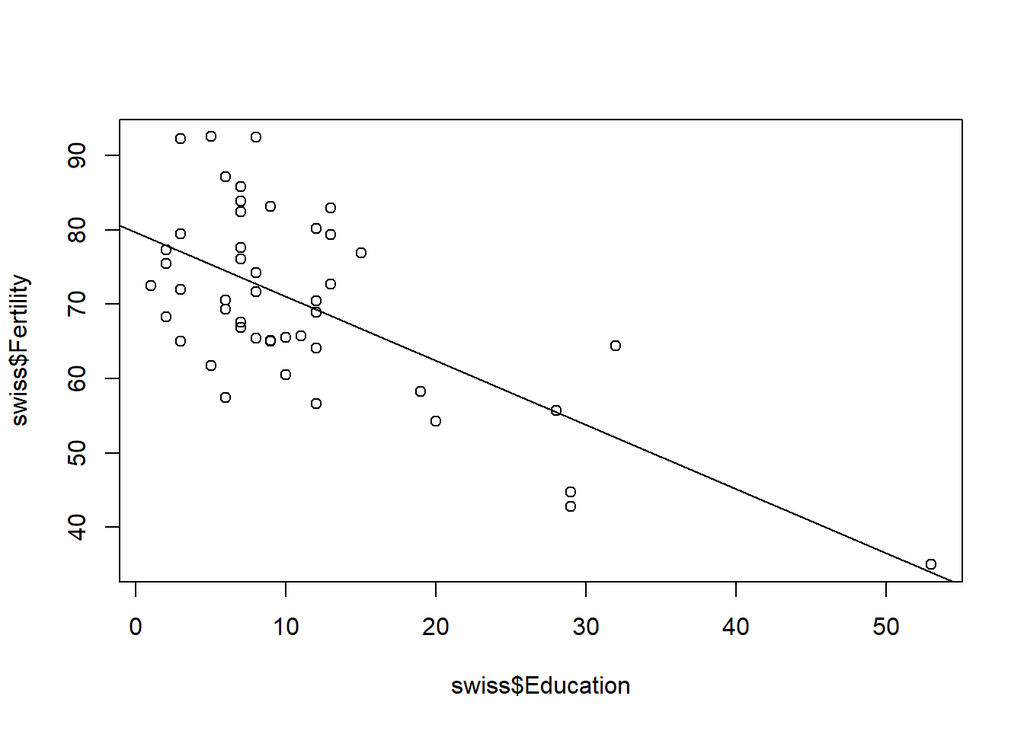

```r
#2) Fertility vs. Education
plot(swiss$Education, swiss$Fertility)
#Add line
abline(lm(swiss$Fertility ~ swiss$Education))
```

Now we will create the same plot using ggplot()

[Code] coef(lm(~, data = ))

ggplot(data = ) + geom_point(mapping = aes()) + geom_abline(slope = , intercept = )

[Example]

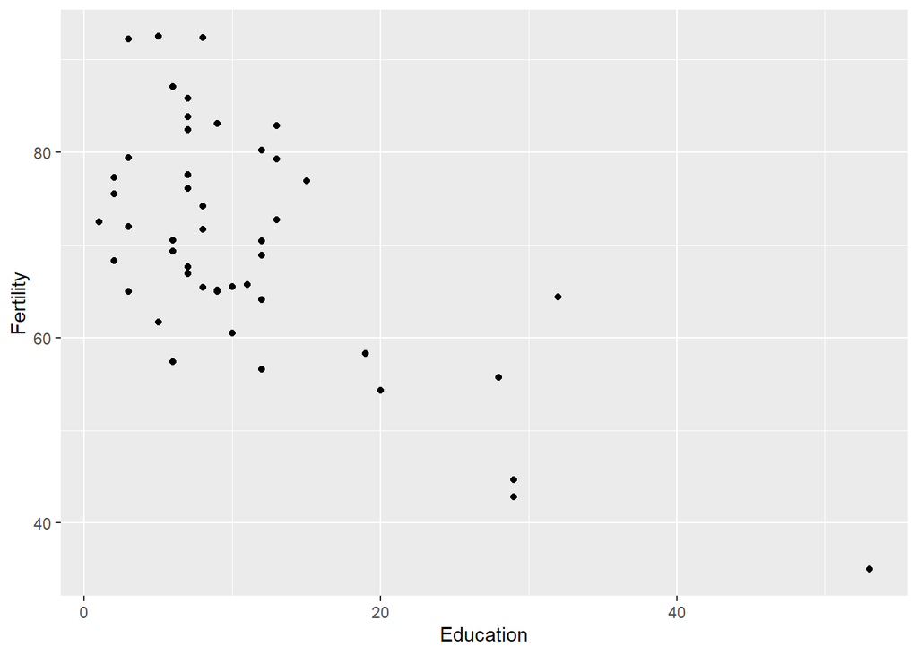

```r
ggplot(data = swiss) +
  geom_point(mapping = aes(x = Education, y = Fertility))
```

```r
#Find slope and intercept using coef() function
coef(lm(Fertility ~ Education, data = swiss))
```

```
## (Intercept)   Education
##  79.6100585  -0.8623503
```

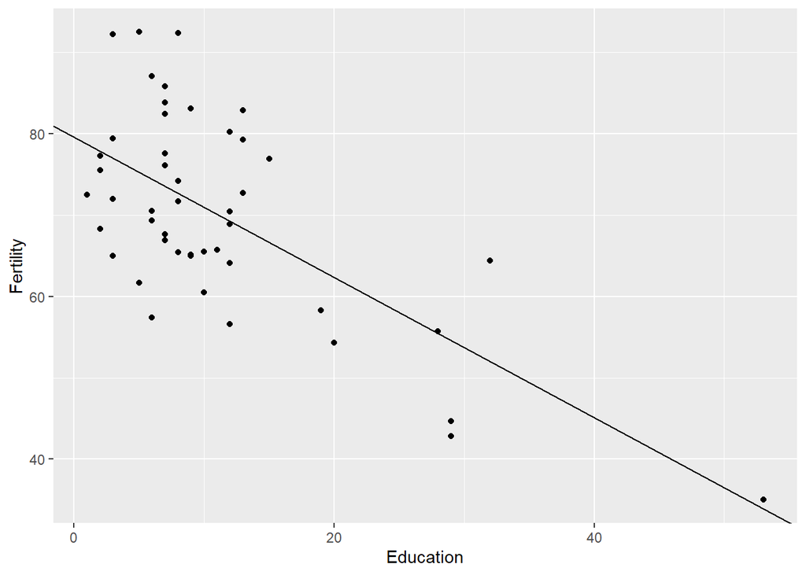

```r
ggplot(data = swiss) +
  geom_point(mapping = aes(x = Education, y = Fertility)) +
  geom_abline(slope = -0.862, intercept = 79.61)
```

*More information about the line can be found in the posting for the linear regression.